# Caso: Donaciones de exalumnos Grupo 3

Johnny Sánchez,Nury Rodriguez .

Maestría en inteligencia de negocios.

Modelos estadísticos aplicados.

26 de octubre de 2022

# 1 Contextualización.

Los datos analizados corresponden al registro de donaciones realizadas por exalumnos a una universidad privada de artes liberales del medio oeste. Los datos contienen las contribuciones realizadas entre los años 2000 y 2004 por parte de 1230 ex alumnos vivos de cinco promociones entre el año 1957 a 1997.

# 2 Variables de estudio.

El conjunto de datos incluye 11 variables. Las cuales se describen a continuación:

| Variable | Código | Descripción | Escala | Naturaleza |
| --- | --- | --- | --- | --- |
| Género | Gender | Género del exalumno | categorico | caracter |
| Cohorte | Class Year | Año de ingreso | cuantitativo | numerico |
| Estado civil | Marital Status | Estado civil del exalumno | categorico | caracter |
| Carrera universitaria | Major | Área del conocimiento | categorico | caracter |
| Grados posteriores | Next Degree | Estudios superiores | categorico | caracter |
| Donación 2004 | FY04Giving | Donación en el año 2004 (dólares) | cuantitativo | numerico |
| Donación 2003 | FY03Giving | Donación en el año 2003 (dólares) | cuantitativo | numerico |
| Donación 2002 | FY02Giving | Donación en el año 2002 (dólares) | cuantitativo | numerico |
| Donación 2001 | FY01Giving | Donación en el año 2001 (dólares) | cuantitativo | numerico |
| Donación 2000 | FY00Giving | Donación en el año 2000 (dólares) | cuantitativo | numerico |
| Asistencia | AttendenceEvent | Eventos de recaudación de fondos | cuantitativo | numerico |

Todas la variables juegan un papel importante para preveer el éxito de futuras campañas de recaudación de fondos.

# 3 Análisis exploratorio.

- Código para visulizar los cinco primeros registros de la base de datos.

```
##   Gender Class.Year Marital.Status   Major Next.Degree FY04Giving FY03Giving
## 1      M       1957              M History         LLB       2500       2500
## 2      M       1957              M Physics          MS       5000       5000
## 3      F       1957              M   Music        NONE       5000       5000
## 4      M       1957              M History        NONE          0       5100
## 5      M       1957              M Biology          MD       1000       1000
##   FY02Giving FY01Giving FY00Giving AttendenceEvent
## 1       1400      12060      12000               1
## 2       5000       5000      10000               1
## 3       5000       5000      10000               1
## 4        200        200          0               1
## 5       1000       1005       1000               1
```

- Código para identificar y eliminar datos faltantes de la base.Código para anexar al tibble contribution la columna con la numeración secuencial de los exalumnos. Consolidación de una base de datos que no contenga valores perdidos.

```r
sum(is.na(contribution))
```

```
## [1] 0
```

```r
contribution<-contribution%>%
mutate(Codigo_exalumno=seq(1:1230))
dim(contribution)
```

```
## [1] 1230   12
```

```r
contribution2<-contribution
```

- Se realiza cambio de nombres de columnas al idioma español

```r
names(contribution2)[1:5]<-c("Genero","Cohorte","Estado_civil","Titulo","Posgrado")
names(contribution2)[11:12]<-c("Asistencia_eventos","Cod_exalumno")
```

- En la variable Genero se cambian las observaciones M y F por Masculino y Femenino respectivamente.

```r
contribution2$Genero<-gsub("M","Masculino",contribution2$Genero)
  contribution2$Genero<-gsub("F","Femenino",contribution2$Genero)
```

- Se transforman la variables categóricas en factores.

```r
contribution2<-contribution2%>%
  mutate(Genero=as.factor(Genero),Cohorte=as.factor(Cohorte),
         Estado_civil=as.factor(Estado_civil),Titulo=as.factor(Titulo),
         Posgrado=as.factor(Posgrado),Asistencia_eventos=as.factor(Asistencia_eventos),
         Cod_exalumno=as.factor(Cod_exalumno))
```

# 4 Análisis descriptivo.

- Construir una tabla o un gráfico que permita saber cuántos exalumnos se tienen por cohorte. Interpreten a la luz del contexto.

```r
contribution2%>%
  group_by(Cohorte)%>%
  summarise(cantidad_exalumnos=n(),.groups='drop')
```

```
## # A tibble: 5 × 2
##   Cohorte cantidad_exalumnos
##   <fct>                <int>
## 1 1957                   127
## 2 1967                   222
## 3 1977                   243
## 4 1987                   277
## 5 1997                   361
```

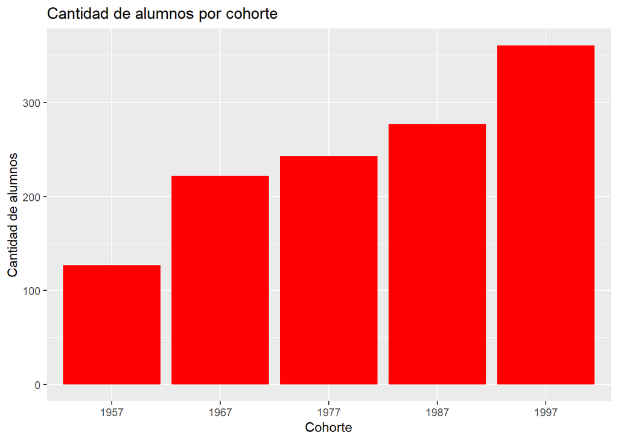

```r
ggplot(data=contribution2)+
  geom_bar(mapping = aes(Cohorte),fill="Red")+
  labs(title="Cantidad de alumnos por cohorte",
       x="Cohorte",
       y="Cantidad de alumnos")
```

**Interpretación**:El cohorte de menor cantidad de alumnos fue en el año 1957 debido a que no se tuvieron en cuenta exalumnos fallecidos y en ésta época la oferta académica era mucho menor.

- Se cambian los nombres de las variables FYxxGiving por años de contribución.

```r
names(contribution2)[6:10]<-c("year_2004","year_2003","year_2002","year_2001","year_2000")
```

- Crear una nueva variable con el nombre **Tgiving**. Esta variable corresponde al total de las contribuciones de cada graduado. Calculen los estadísticos descriptivos (media, mediana, desviación, coeficiente de variación, mínimo y máximo) de esta variable. Utilicen funciones como **round()**, **data.frame()** y **cbind()** (u otras que ustedes consulten) para presentar los resultados redondeados a dos cifras decimales y organizados en una tabla. Interpreten los resultados a la luz del contexto.

[output not shown]

```r
Minimo<-data.frame("Minimo"=round(min(contribution2$TDonaciones,na.rm=FALSE),2))
```

[output not shown]

```
##       0%      10%      20%      30%      40%      50%      60%      70%
##      0.0      0.0      0.0      0.0     25.0     75.0    150.8    275.0
##      80%      90%     100%
##    554.2   1050.0 171870.1
```

**Interpretación:** Por la presencia de datos atípicos en el dataframe, el cálcuo de los deciles no está bien centrado.

- Tener en cuenta que hay un número considerable de exalumnos que no han contribuido y unos pocos que han realizado aportes muy altos. Por ello, es pertinente excluir del análisis contribuciones totales que sean $0 o superiores a $4000. Esto permite focalizar el análisis en las donaciones más frecuentes de los exalumnos. Construyan un histograma junto con la función de densidad, para visualizar las contribuciones totales (variable **TGiving**) excluyendo los valores descritos. Interpreten los resultados a la luz del contexto.

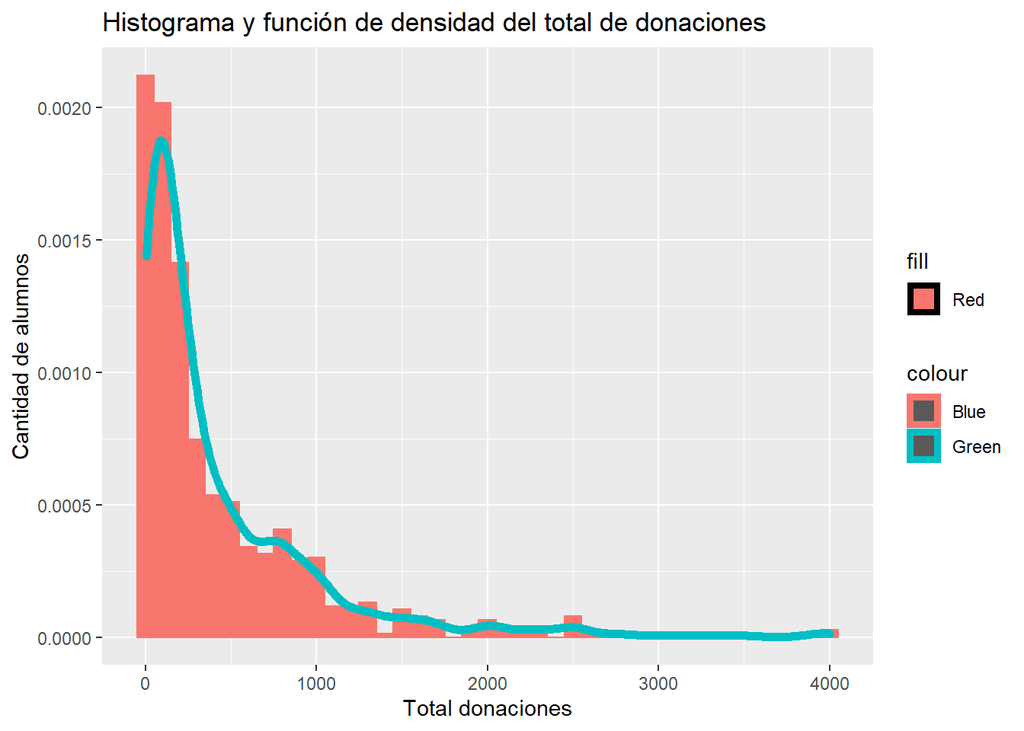

```r
contribution3<-contribution2%>%
  filter(TDonaciones>0,TDonaciones<=4000)
ggplot(data =contribution3,mapping = aes(x =TDonaciones , y = ..density..)) +
  geom_histogram(mapping = aes(color = "Blue",fill="Red"),binwidth=100)+
  geom_density(mapping=aes(color="Green"),size=2)+
  labs(title="Histograma y función de densidad del total de donaciones",
       x="Total donaciones",
       y="Cantidad de alumnos")
```

**Interpretación:** Se obtiene una distribución sesgada a la derecha.La media tiene un valor mayor a la mediana. Es una distribución que se aleja de la normalidad.

- Describir las características de los exalumnos que han realizado las contribuciones más altas durante el 2000-2004. Para ello seleccionen los egresados que hicieron una contribución total (variable **TGiving**) de al menos $20000 durante el periodo de interés.

```r
contribution4<-contribution2%>%
  filter(TDonaciones>=20000)

which(is.na(contribution))
```

```
## integer(0)
```

**Interpretación:**

- Elaborar diagramas de caja que permita comparar la donación total (variable **TGiving**) durante los 5 años discriminando por cohorte, género, estado civil y asistencia a eventos de recaudación de fondos. Con la opción **outline** omitan las observaciones periféricas (datos atípicos, es decir, aquellos donantes que contribuyen generosamente). Comparen los cuatro gráficos, destaquen diferencias y similitudes entre grupos.

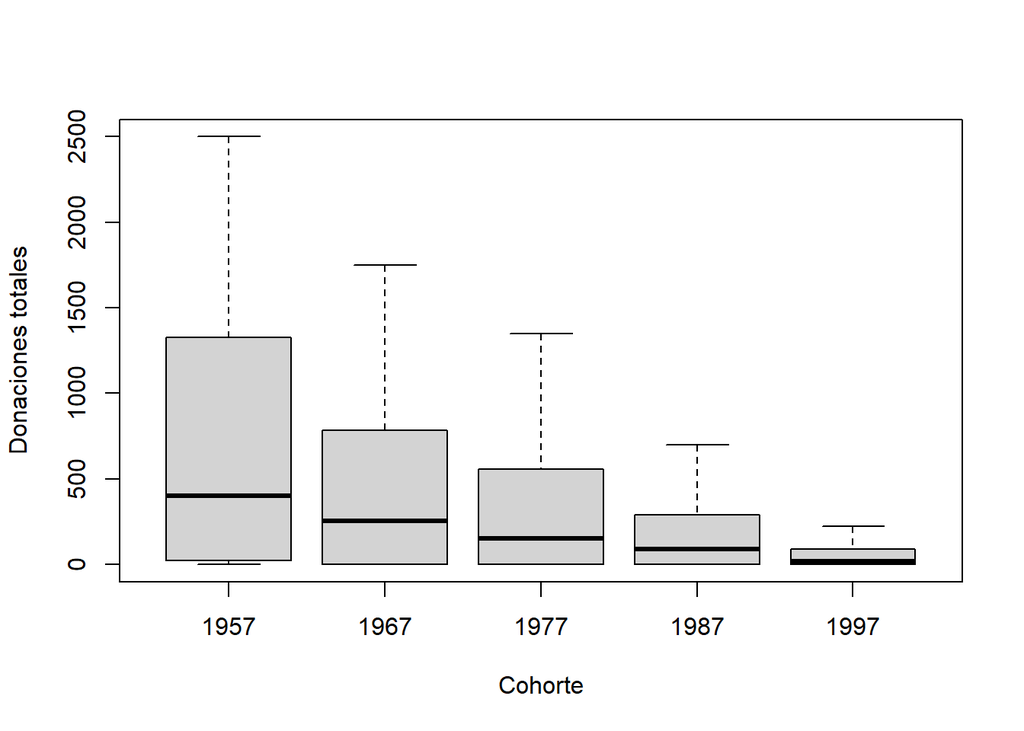

```r
boxplot(contribution2$TDonaciones~contribution2$Cohorte,horizontal=FALSE,
        outline=FALSE,xlab="Cohorte",ylab = "Donaciones totales")
```

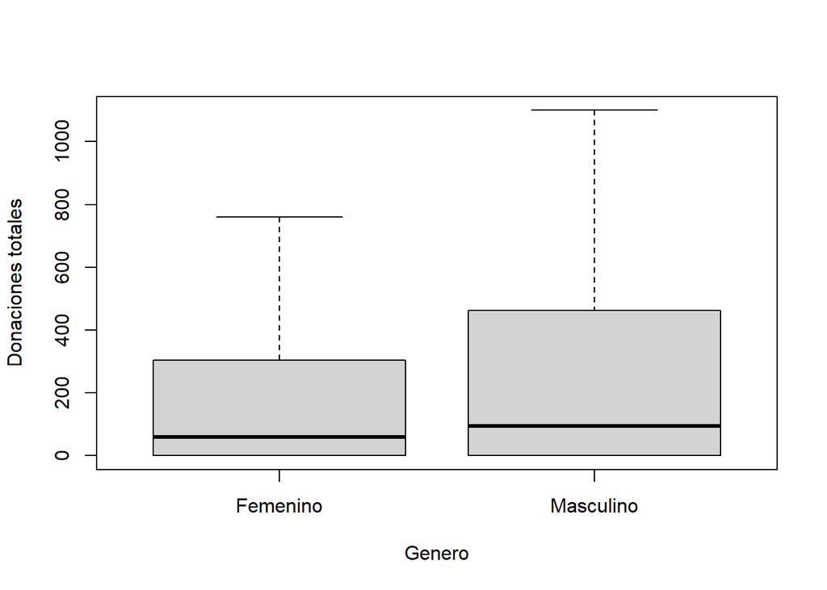

```r
boxplot(contribution2$TDonaciones~contribution2$Genero,horizontal=FALSE,
        outline=FALSE,xlab="Genero",ylab = "Donaciones totales")
```

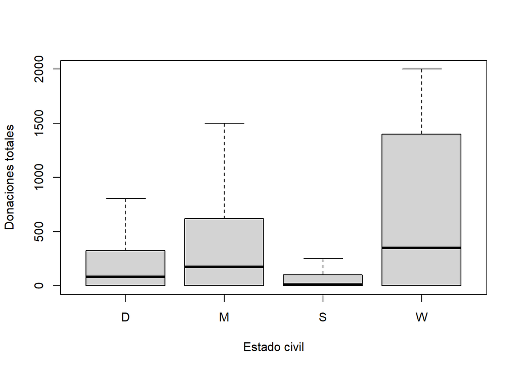

```r
boxplot(contribution2$TDonaciones~contribution2$Estado_civil,horizontal=FALSE,
        outline=FALSE,xlab="Estado civil",ylab = "Donaciones totales")
```

[figure not shown]

```r
boxplot(contribution2$TDonaciones~contribution2$Asistencia_eventos,horizontal=FALSE,
        outline=FALSE,xlab="Estado civil",ylab = "Donaciones totales")
```

**Interpretación:**

- Construir una tabla que de cuenta del número de estudiantes y el promedio del total de contribuciones (variable **TGiving**) por carrera universitaria. ¿Cuáles son las carreras que tienen un mayor número de exalumnos en la base de datos? ¿cuáles son las que tienen una contribución total promedio más alta? Para calcular promedio por grupos pueden utilizar la función **tapply()**.

```r
contribution2%>%
  group_by(Titulo)%>%
  summarise(cantidad_exalumnos=n(),.groups='drop')
```

```
## # A tibble: 46 × 2
##    Titulo                 cantidad_exalumnos
##    <fct>                               <int>
##  1 American Studies                       29
##  2 Anthropology                           44
##  3 Art                                    39
##  4 Biology                               115
##  5 Chemistry                              63
##  6 Chemistry-Zoology                       3
##  7 Chinese                                 2
##  8 Classics                                9
##  9 Comparative Literature                  2
## 10 Computer Science                        4
## # … with 36 more rows
```

```r
contribution2%>%
  group_by(Titulo)%>%
  summarise(Promedio_Exalumnos=mean(TDonaciones),.groups='drop')
```

```
## # A tibble: 46 × 2
##    Titulo                 Promedio_Exalumnos
##    <fct>                               <dbl>
##  1 American Studies                     451.
##  2 Anthropology                         164.
##  3 Art                                  164.
##  4 Biology                              551.
##  5 Chemistry                            422.
##  6 Chemistry-Zoology                  11083.
##  7 Chinese                              132.
##  8 Classics                             767
##  9 Comparative Literature                 0
## 10 Computer Science                     737
## # … with 36 more rows
```

```r
promedio_titulos_TDonaciones<-tapply(contribution2$TDonaciones, contribution2$Titulo, mean)

promedio_titulos_TDonaciones
```

```
##          American Studies              Anthropology                       Art
##                  451.2845                  164.2500                  164.0769
##                   Biology                 Chemistry         Chemistry-Zoology
##                  551.0024                  421.8368                11083.3333
##                   Chinese                  Classics    Comparative Literature
##                  132.5000                  767.0000                    0.0000
##          Computer Science                 Economics        Economics-Business
##                  737.0000                 1166.9149                 4334.6617
##  Economics-Regional Stds.                 Education               Engineering
##                  350.0000                  473.6667                  100.0000
##                   English        English-Journalism                    French
##                  397.1862                 1897.4400                  267.0870
##           General Science   General Science-Biology General Science-Chemistry
##                  608.7500                  210.5000                  199.2000
##      General Science-Math   General Science-Physics    General Science-Psycho
##                    0.0000                    0.0000                  477.0000
##                    German                   History               Independent
##                  259.4615                 1782.3447                  347.6190
##               Mathematics       Mathematics-Physics                     Music
##                  501.2500                57570.0200                 1221.9000
##                Philosophy       Philosophy-Religion        Physical Education
##                  203.3636                  244.5556                 1886.0000
##                   Physics  Pol. Sci.-Regional Stds.         Political Science
##                 1842.1429                    0.0000                  719.0517
##                Psychology         Religious Studies                   Russian
##                  554.5177                  139.5652                  380.0000
##                 Sociology    Sociology-Anthropology                   Spanish
##                  626.9218                  344.5000                  211.4815
##      Speech (Drama, etc.)         Speech Correction                   Theatre
##                10699.3300                   56.2500                  229.4762
##                   Zoology
##                   27.5000
```

```r
max(promedio_titulos_TDonaciones)
```

```
## [1] 57570.02
```

**Interpretación:**

- Crear una variable indicadora (pueden denominarla **TGivingIND**) que clasifique los exalumnos en contribuyentes (1) y no contribuyentes (0). Utilizando esta variable elaboren un mosaico para visualizar la proporción de contribuyentes por cohorte y otro para visualizar la proporción según la asistencia a eventos. Interpreten lo que observan en estos gráficos.

```r
# Crear la variable indicadora.

contribution5<-contribution2

#Creación de variable indicadora TDonacionesIND

contribution5<-contribution5%>%
  mutate(TDonacionesIND=TDonaciones)

contribution5<-contribution5%>%
  mutate(TDonacionesIND=
           ifelse(TDonacionesIND>0 ,"1", "0"))
```

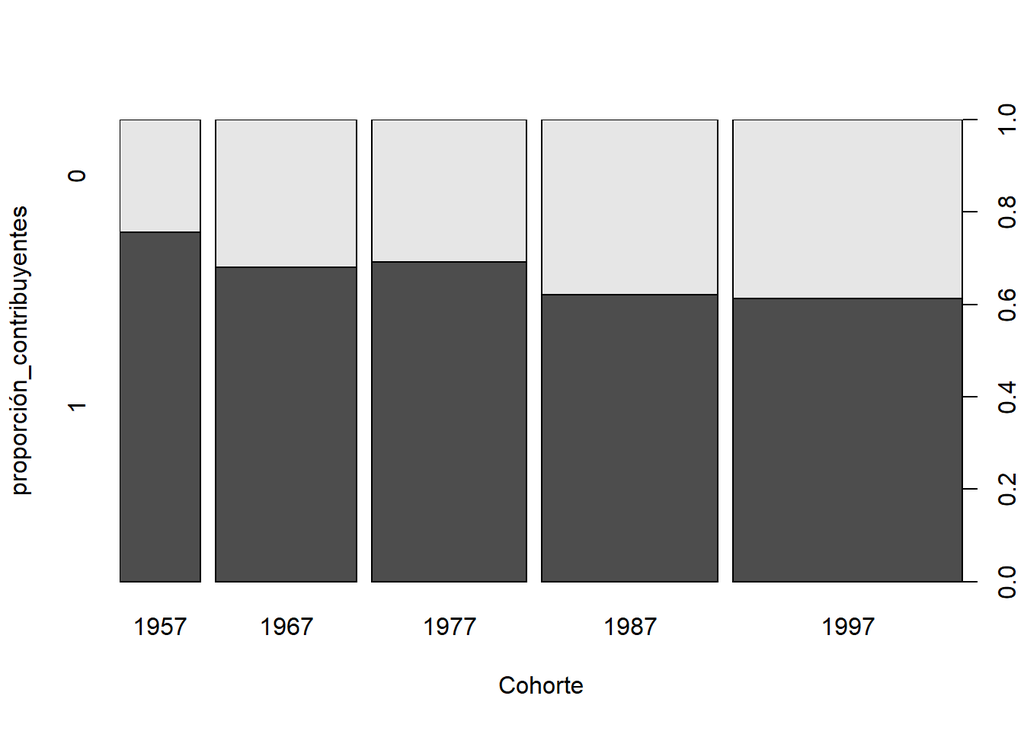

```r
contribution5$TDonacionesIND<-as.factor(contribution5$TDonacionesIND)


#Mosaico proporción contribuyentes por cohorte

plot(x=contribution5$Cohorte,y=contribution5$TDonacionesIND,xlab="Cohorte",ylab="proporción_contribuyentes")
```

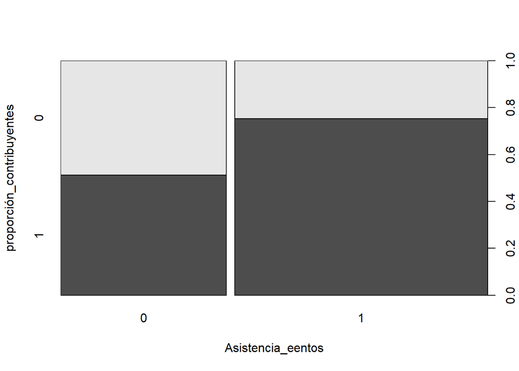

```r
#Mosaico proporción contribuyentes por asistencia a eventos

plot(x=contribution5$Asistencia_eventos,y=contribution5$TDonacionesIND,xlab="Asistencia_eentos",ylab="proporción_contribuyentes")
```

```r
# Mosaico para la proporción de contribuyentes según asistencia a eventos.
```

**Interpretación:**

# 5 Discusión.